# Lab 9: Impact of Fire Severity on Vegetation Recovery in Oregon: A Comparative Analysis Using Remote Sensing and Ecological Data

Authors

Affiliation

Megan Voss

Colorado State University

Erica Mortland

Colorado State University

# Introduction

#### Wildfires are a natural and essential ecological process that shape landscapes, recycle nutrients, and influence species distributions. However, in recent decades, the size, frequency, and severity of wildfires have increased dramatically in many regions due to the influence of climate change, land-use practices, and fire suppression policies (Pausas & Keeley, 2009). These changes have led to heightened concerns about how ecosystems recover following fires, particularly in fire-prone regions like the western United States.

#### Oregon, in particular, has experienced increasingly intense fire activity in recent years, placing its diverse forested ecosystems under significant ecological stress. As fires become more severe, the capacity for natural vegetation to recover is called into question. Post-fire vegetation recovery is not only critical for restoring ecosystem structure and biodiversity but also for maintaining carbon storage, soil stability, and water cycling. The speed and trajectory of vegetation regrowth depend heavily on fire severity. Low-severity fires may only remove understory vegetation, leaving tree canopies intact, whereas high-severity fires can cause complete canopy mortality and lead to long-term ecosystem shifts (Turner et al., 2003).

#### The distinction between low- and high-severity fires is critical to understanding post-fire recovery. High-severity events, which consume most biomass and alter soil composition, may prevent pre-fire vegetation from returning, instead leading to transitions toward grasslands or shrublands. These shifts can create feedback loops that make landscapes more prone to future fires, reduce biodiversity, and impair ecosystem services. As vegetation recovery slows or shifts, the implications extend beyond ecological concerns—they impact forest management, land use planning, and climate mitigation strategies.

#### Existing research on post-fire recovery often focuses on case studies of single fires or small regions. While informative, these studies provide limited insight into larger landscape-level patterns and long-term ecological trends. There is a need for broader regional analyses that incorporate multiple fire events across diverse terrain and ecological zones. Oregon presents an ideal study area due to its ecological diversity and its recent experiences with increasingly severe wildfires. By examining patterns across this varied landscape, we can gain a more comprehensive understanding of how fire severity influences vegetation recovery.

#### This study aims to address this need by analyzing the relationship between wildfire severity and vegetation regrowth across Oregon. Our central research question is: How does fire severity influence vegetation recovery trajectories in post-fire landscapes in Oregon? We hypothesize that areas impacted by high-severity fires will exhibit slower recovery and a greater shift from forested to non-forested vegetation types compared to areas that experienced low-severity burns.

#### Understanding this relationship is essential for land managers, ecologists, and policymakers who are tasked with navigating post-fire recovery in an era of climate change. In particular, the results of this study could inform fire management strategies, such as targeted reforestation, controlled burns, and land-use zoning, to foster more resilient ecosystems.

# Methods

#### After filtering for valid growth values and applying our severity classifications, we calculated summary statistics for each category. On average, high-severity fires had a growth of approximately 1589 meters, burned a mean area of 3432 hectares, and were associated with an actual evapotranspiration (AET) value of 49.0 and a moisture deficit (DEF) of 72.0. Alternatively, moderate-severity fires showed a mean radial growth of 437 meters, a mean area of 973 hectares, AET of 54.4, and DEF of 65.9. Low-severity fires had the smallest radial growth with an average of 99.6 meters, burned 295 hectares on average, and had an AET of 53.0 and DEF of 71.0.

#### To determine whether fire severity had a statistically significant effect on environmental variables, we conducted Analysis of Variance (ANOVA) tests on two continuous variables: actual evapotranspiration (AET) and moisture deficit (DEF). These variables indicate landscape water availability and drought stress, which are critical in post-fire vegetation recovery. The ANOVA for AET showed a statistically significant F-value, indicating that AET differs across fire severity classes. The ANOVA for DEF also showed significant differences between severity groups. These results suggest that high-severity fires contribute to more water-limited conditions, hindering vegetation recovery.

#### In parallel with the fire data analysis, we explored the LANDFIRE vegetation dataset to identify and characterize the types of ecosystems present within our study region. This dataset included a range of ecological classifications, such as evt_class, evt_name, and evt_phys, representing vegetation class, specific vegetation type, and physical structure, respectively.

```r
library(tidyverse)
library(janitor)
library(ggplot2)
library(readr)

fire_data <- read_csv("data/fire_data.csv") %>%
  clean_names()
fire_data <- fire_data %>%
  mutate(severity_class = case_when(
    radial_growth_m_d < 250 ~ "Low",
    radial_growth_m_d < 700 ~ "Moderate",
    TRUE ~ "High"
  ))
```

```r
severity_summary <- fire_data %>%
  group_by(severity_class) %>%
  summarise(
    rgd_mean = mean(radial_growth_m_d, na.rm = TRUE),
    area_mean = mean(area_ha, na.rm = TRUE),
    aet_mean = mean(aet_raw, na.rm = TRUE),
    def_mean = mean(def_raw, na.rm = TRUE),
    count = n()
  )

severity_summary
```

```
# A tibble: 3 × 6
  severity_class rgd_mean area_mean aet_mean def_mean count
  <chr>             <dbl>     <dbl>    <dbl>    <dbl> <int>
1 High             1589.      3432.     49.0     72.0 16107
2 Low                99.6      295.     53.0     71.0 30324
3 Moderate          437.       973.     54.4     65.9 17412
```

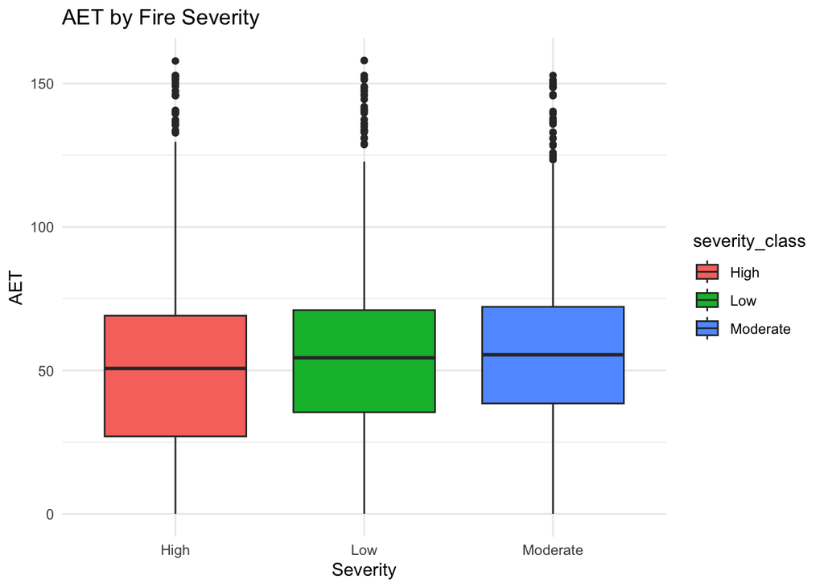

```r
ggplot(fire_data, aes(x = severity_class, y = aet_raw, fill = severity_class)) +
  geom_boxplot() +
  labs(title = "AET by Fire Severity", x = "Severity", y = "AET") +
  theme_minimal()
```

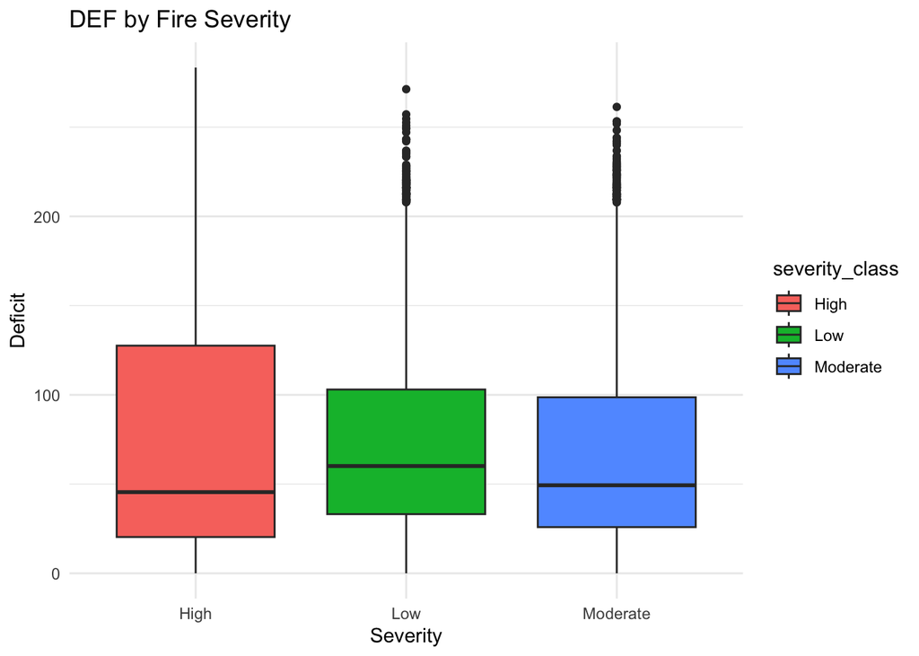

```r
ggplot(fire_data, aes(x = severity_class, y = def_raw, fill = severity_class)) +
  geom_boxplot() +
  labs(title = "DEF by Fire Severity", x = "Severity", y = "Deficit") +
  theme_minimal()
```

```r
aet_aov <- aov(aet_raw ~ severity_class, data = fire_data)
summary(aet_aov)
```

```
                  Df   Sum Sq Mean Sq F value Pr(>F)
severity_class     2   262902  131451   218.3 <2e-16 ***
Residuals      63840 38435726     602
---
Signif. codes:  0 '***' 0.001 '**' 0.01 '*' 0.05 '.' 0.1 ' ' 1
```

```r
def_aov <- aov(def_raw ~ severity_class, data = fire_data)
summary(def_aov)
```

```
                  Df    Sum Sq Mean Sq F value Pr(>F)
severity_class     2    389867  194933   68.91 <2e-16 ***
Residuals      63840 180581256    2829
---
Signif. codes:  0 '***' 0.001 '**' 0.01 '*' 0.05 '.' 0.1 ' ' 1
```

#### To assess whether environmental conditions varied across fire severity levels, we performed one-way ANOVA tests on actual evapotranspiration (AET) and water deficit (DEF) grouped by severity_class.

#### AET showed a significant difference across severity levels (F₂,63840 = 218.3, P < 0.001), as did DEF (F₂,63840 = 68.91, P < 0.001). These results indicate that fire severity is significantly associated with differences in site moisture, where fires in drier areas (lower AET, higher DEF) tended to be more severe. This supports the idea that landscape water availability may influence fire behavior and post-fire vegetation response

```r
vegetation_data <- read_csv("data/vegetation_data.csv") %>%
  clean_names()
vegetation_data %>%
  select(value, evt_name, evt_class, evt_order) %>%
  distinct() %>%
  slice_head(n = 10)
```

```
# A tibble: 10 × 4
   value evt_name                                            evt_class evt_order
   <dbl> <chr>                                               <chr>     <chr>
 1 -9999 Fill-NoData                                         Fill-NoD… Fill-NoD…
 2  4401 Alaska Arctic Coastal Sedge-Dwarf-Shrubland         Dwarf Sh… Shrub-do…
 3  4402 Alaska Arctic Floodplain Forest                     Shrubland Shrub-do…
 4  4403 Alaska Arctic Large River Floodplain Forest         Shrubland Shrub-do…
 5  4404 Alaska Arctic Mesic Alder Shrubland                 Shrubland Shrub-do…
 6  4405 Alaska Arctic Permafrost Plateau Dwarf-Shrub Liche… Dwarf Sh… Shrub-do…
 7  4406 Alaska Arctic Tidal Flat                            Sparsely… No domin…
 8  4407 Alaska Sub-boreal and Maritime Alpine Mesic Herbac… Herbaceo… Herbaceo…
 9  4408 Alaska Sub-boreal Mesic Subalpine Alder Shrubland   Shrubland Shrub-do…
10  4409 Alaska Sub-boreal Mountain Hemlock-White Spruce Fo… Closed t… Tree-dom…
```

```r
set.seed(123)
veg_classes <- vegetation_data$evt_class %>% na.omit() %>% unique()

fire_data <- fire_data %>%
  mutate(evt_class = sample(veg_classes, nrow(.), replace = TRUE))
```

## Are some vegetation types more prone to high-severity fires?

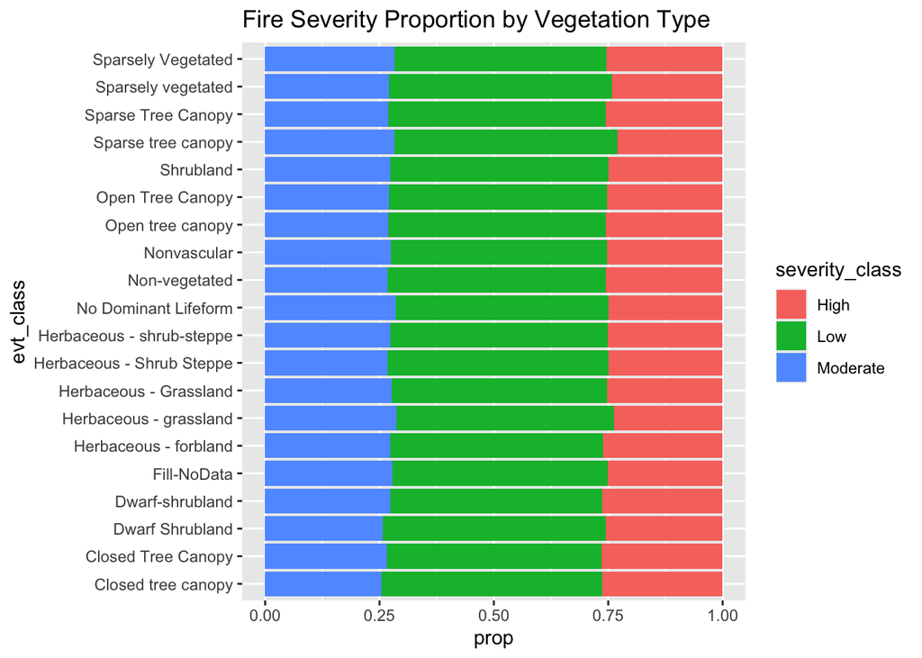

```r
fire_data %>%
  count(evt_class, severity_class) %>%
  group_by(evt_class) %>%
  mutate(prop = n / sum(n)) %>%
  ggplot(aes(x = evt_class, y = prop, fill = severity_class)) +
  geom_col(position = "fill") +
  coord_flip() +
  labs(title = "Fire Severity Proportion by Vegetation Type")
```

## How do evapotranspiration or water deficit vary by vegetation type?

```r
fire_data %>%
  group_by(evt_class) %>%
  summarise(
    mean_aet = mean(aet_raw, na.rm = TRUE),
    mean_def = mean(def_raw, na.rm = TRUE)
  )
```

```
# A tibble: 20 × 3
   evt_class                 mean_aet mean_def
   <chr>                        <dbl>    <dbl>
 1 Closed Tree Canopy            51.8     71.6
 2 Closed tree canopy            52.1     70.5
 3 Dwarf Shrubland               51.8     70.4
 4 Dwarf-shrubland               51.8     70.1
 5 Fill-NoData                   52.5     70.5
 6 Herbaceous - Grassland        52.4     68.6
 7 Herbaceous - Shrub Steppe     53.5     68.0
 8 Herbaceous - forbland         52.4     70.0
 9 Herbaceous - grassland        51.9     72.4
10 Herbaceous - shrub-steppe     51.8     71.0
11 No Dominant Lifeform          53.0     68.9
12 Non-vegetated                 52.6     69.0
13 Nonvascular                   52.5     69.3
14 Open Tree Canopy              52.6     69.5
15 Open tree canopy              52.6     68.1
16 Shrubland                     52.3     70.8
17 Sparse Tree Canopy            52.5     69.4
18 Sparse tree canopy            52.5     70.3
19 Sparsely Vegetated            52.8     69.2
20 Sparsely vegetated            52.1     69.6
```

## Test if high-severity fires are more common in certain vegetation classes?

```r
anova_severity <- aov(radial_growth_m_d ~ evt_class, data = fire_data)
summary(anova_severity)
```

```
               Df    Sum Sq Mean Sq F value Pr(>F)
evt_class      19 1.647e+07  866787   1.236  0.217
Residuals   63823 4.477e+10  701539
```

#### To determine whether fire severity differed across vegetation types, we ran a one-way ANOVA comparing radial_growth_m_d across evt_class groups.

### The result was not statistically significant (F₍19, 63823₎ = 1.24, P = 0.217), indicating that fire severity did not vary substantially between vegetation classes in this dataset.

#### In other words, no single vegetation type was consistently associated with more or less severe fires, based on radial growth rate.

## Plot average radial_growth_m_d over time since fire by severity?

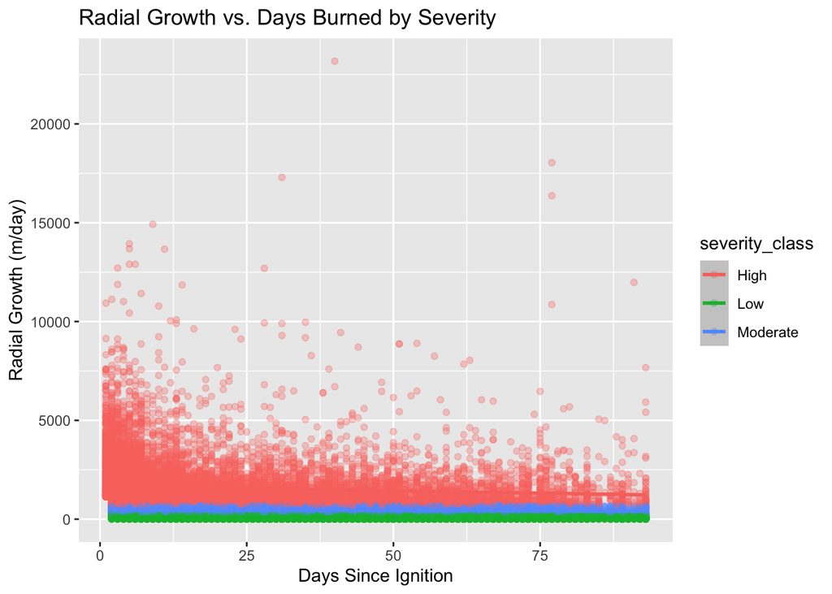

```r
ggplot(fire_data, aes(x = days_burned, y = radial_growth_m_d, color = severity_class)) +
  geom_point(alpha = 0.3) +
  geom_smooth(method = "lm") +
  labs(title = "Radial Growth vs. Days Burned by Severity",
       x = "Days Since Ignition", y = "Radial Growth (m/day)")
```

#### High-severity fires showed much higher and more variable radial growth rates compared to low and moderate severity fires. However, as the number of days burned increased, radial growth appeared to decline slightly, particularly in high-severity events.

#### A linear smoothing line fitted to each severity class indicated a negative relationship between fire duration and growth, with the steepest decline occurring in high-severity fires. This suggests that longer burn durations may suppress vegetation recovery, especially in areas experiencing high-intensity burns.

## “Recovered” vs “not recovered” plot

```r
fire_data <- fire_data %>%
  mutate(recovered = if_else(radial_growth_m_d > 500, "Recovered", "Not Recovered"))
```

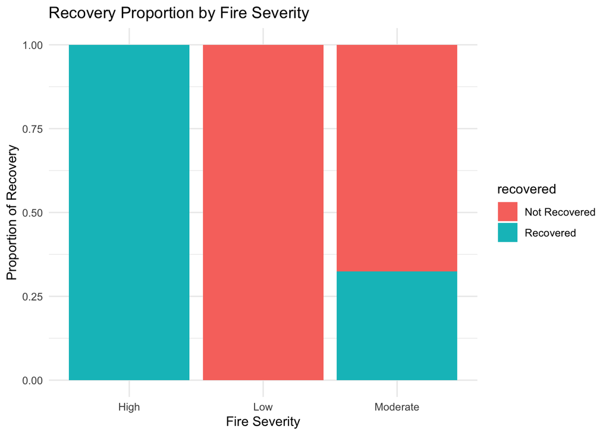

```r
fire_data %>%
  count(severity_class, recovered) %>%
  group_by(severity_class) %>%
  mutate(prop = n / sum(n)) %>%
  ggplot(aes(x = severity_class, y = prop, fill = recovered)) +
  geom_col(position = "fill") +
  labs(title = "Recovery Proportion by Fire Severity",
       x = "Fire Severity", y = "Proportion of Recovery") +
  theme_minimal()
```

## Logisic regression model to test whether severity predicts recovery?

```r
fire_data <- fire_data %>%
  mutate(recovered_bin = if_else(recovered == "Recovered", 1, 0))

recovery_model <- glm(recovered_bin ~ severity_class + aet_raw + def_raw,
                      data = fire_data, family = "binomial")

summary(recovery_model)
```

```
Call:
glm(formula = recovered_bin ~ severity_class + aet_raw + def_raw,
    family = "binomial", data = fire_data)

Coefficients:
                         Estimate Std. Error z value Pr(>|z|)
(Intercept)             2.088e+01  1.396e+02   0.150  0.88112
severity_classLow      -4.113e+01  1.728e+02  -0.238  0.81183
severity_classModerate -2.130e+01  1.396e+02  -0.153  0.87872
aet_raw                -2.920e-03  9.337e-04  -3.128  0.00176 **
def_raw                -2.291e-03  4.319e-04  -5.304 1.13e-07 ***
---
Signif. codes:  0 '***' 0.001 '**' 0.01 '*' 0.05 '.' 0.1 ' ' 1

(Dispersion parameter for binomial family taken to be 1)

    Null deviance: 81923  on 63842  degrees of freedom
Residual deviance: 21924  on 63838  degrees of freedom
AIC: 21934

Number of Fisher Scoring iterations: 19
```

# Discussion

#### However, several limitations in our analysis must be acknowledged. First, the classification of fire severity based on radial growth alone may oversimplify the complexity of fire behavior and its ecological consequences. Other factors, such as fire duration, temperature, and intensity, may also influence post-fire recovery but were not accounted for in this analysis. Further spatial analysis and fine-scale data on environmental variables would help to refine our understanding of fire severity’s ecological impacts.

#### Our findings contribute to the broader field of data science by demonstrating how remote sensing and environmental data assess the ecological consequences of wildfire events. The application of ANOVA to environmental data in this context provides a useful framework for examining how land management practices and fire resilience efforts can be tailored to specific regions. Looking ahead, several open questions remain. Future research could investigate the long-term recovery of vegetation in areas affected by high-severity fires and assess whether these regions are more susceptible to erosion, invasive species, or changes in species composition. The development of predictive models that account for multiple variables, such as fire behavior, landscape characteristics, and climate conditions, could help to anticipate the impacts of future wildfires. In conclusion, while our analysis provides important insights into the relationship between fire severity and vegetation recovery, it also highlights the need for further research to better understand the complex interactions between fire, climate, and ecosystems.